# 13_doubling_time_from_graph

## 13_doubling_time_from_graph

#### Question

1. The doubling time of an exponentially growing function is the amount of time it takes for the population to double.

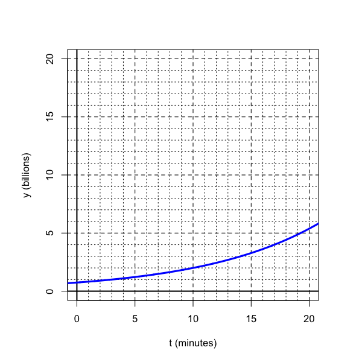

   What is the doubling time (in minutes) of the exponential function graphed above? (The answer is an integer.)

#### Question

2. The doubling time of an exponentially growing function is the amount of time it takes for the population to double.

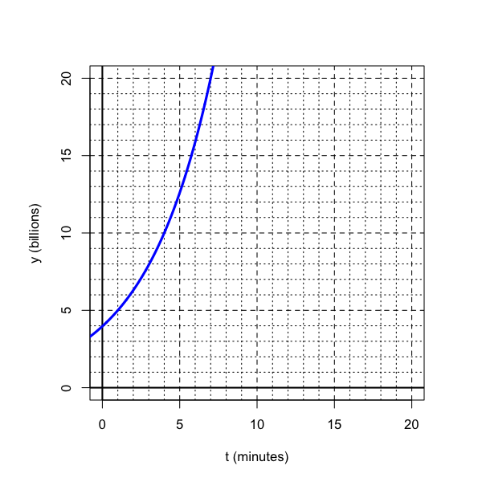

   What is the doubling time (in minutes) of the exponential function graphed above? (The answer is an integer.)

#### Question

3. The doubling time of an exponentially growing function is the amount of time it takes for the population to double.

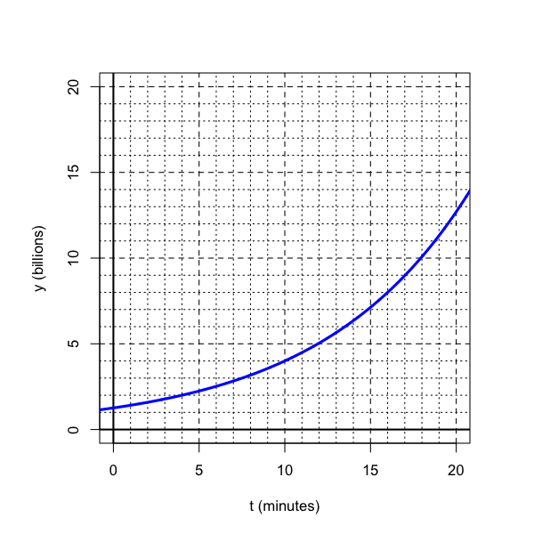

   What is the doubling time (in minutes) of the exponential function graphed above? (The answer is an integer.)

#### Question

4. The doubling time of an exponentially growing function is the amount of time it takes for the population to double.

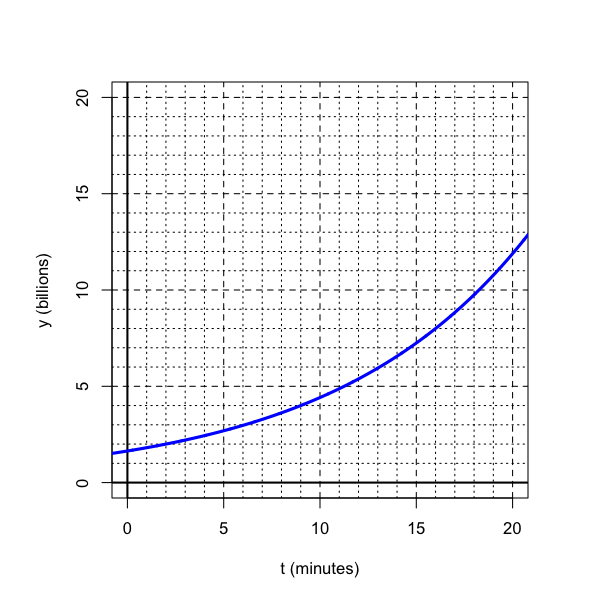

   What is the doubling time (in minutes) of the exponential function graphed above? (The answer is an integer.)

#### Question

5. The doubling time of an exponentially growing function is the amount of time it takes for the population to double.

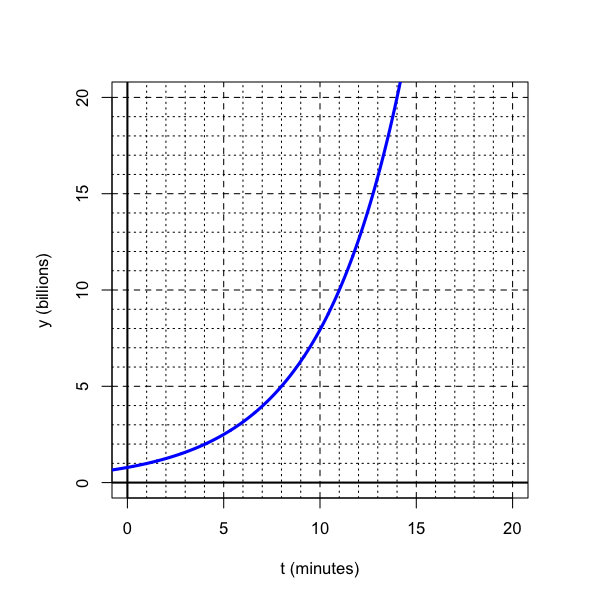

   What is the doubling time (in minutes) of the exponential function graphed above? (The answer is an integer.)

#### Question

6. The doubling time of an exponentially growing function is the amount of time it takes for the population to double.

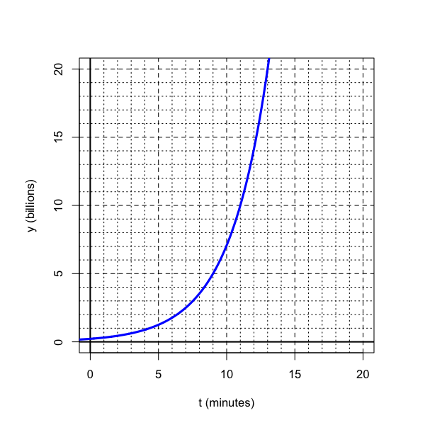

   What is the doubling time (in minutes) of the exponential function graphed above? (The answer is an integer.)

#### Question

7. The doubling time of an exponentially growing function is the amount of time it takes for the population to double.

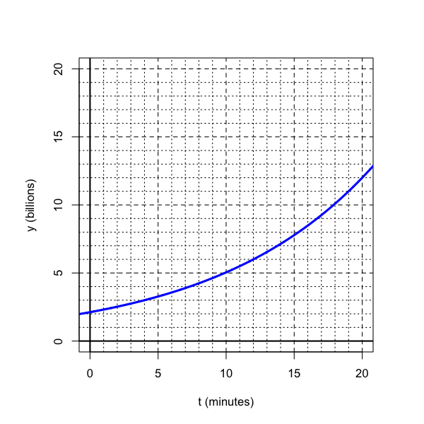

   What is the doubling time (in minutes) of the exponential function graphed above? (The answer is an integer.)

#### Question

8. The doubling time of an exponentially growing function is the amount of time it takes for the population to double.

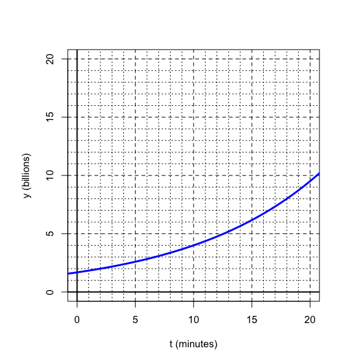

   What is the doubling time (in minutes) of the exponential function graphed above? (The answer is an integer.)